# 5523 shiny assignment

DIYAO CHEN

2020/10/8

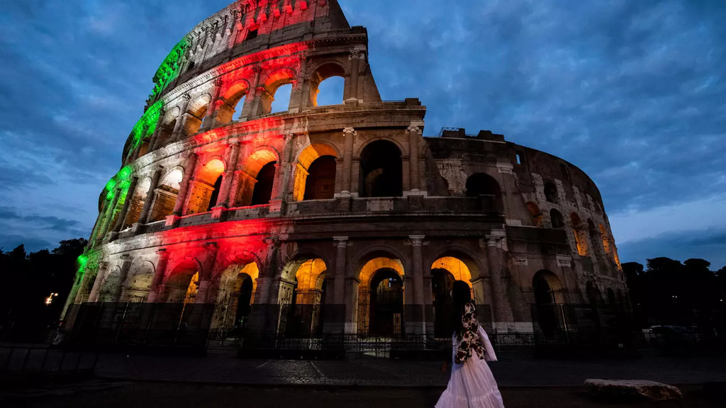

## Introduction

Coronavirus disease 2019 (COVID‑19) is an infectious disease caused by severe acute respiratory syndrome coronavirus 2 (SARS-CoV-2).It was first identified in December 2019 in Wuhan, Hubei, China, and has resulted in an ongoing pandemic. As of 31 August 2020, more than 25.3 million cases have been reported across 188 countries and territories, resulting in more than 848,000 deaths. More than 16.6 million people have recovered.[wikipedia](https://en.wikipedia.org/wiki/Coronavirus_disease_2019)

This app is use to analysis the COVID19 situation in Italy.

## Data description

The dataset used for this analsis was retrieved from covid19italyThe covid19italy R package provides a tidy format dataset of the 2019 Novel Coronavirus COVID-19 (2019-nCoV) pandemic outbreak in Italy. The package includes the following three datasets:

italy_total - daily summary of the outbreak on the national level

italy_region - daily summary of the outbreak on the region level

italy_province - daily summary of the outbreak on the province level

I download the dataset for csv file and collect the data between 24/02/2020 to 07/10/2020,which is the latest situation from Italy.

## The main research

- primary question: What is the situation about COVID19 in Italy(each month)?
- Secondary question: what is the situation for each province

## Conclusion

Overall, the epidemic in Italy has been largely reduced with a series of measures.but the epidemic has rebounded, the situation of COVID19 in Italy is not optimistic. So the government must be increase prevention and control effortst.Let the people return to normal life as soon as possible.

## Reference

1. Coronavirus disease 2019, [wikipedia](https://en.wikipedia.org/wiki/Coronavirus_disease_2019)